# HOMEWORK 1

## Visualization Tools

We are going to plot a pie in which we can see the frequency of cancer diagnosis

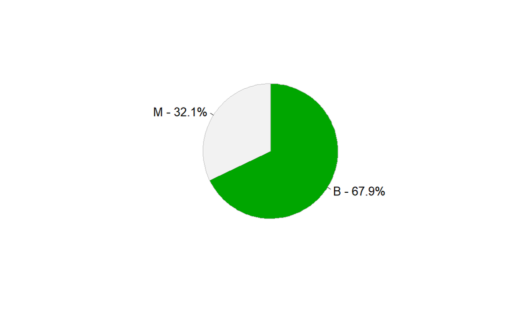

```r
#Create a pie chart
d_table = table(X$diagnosis)
# Create the prop tables and multiply by 100 because we want the results to be percentage
diagnosis.prop.table = prop.table(d_table)*100
# Now, transform the prop table into data frame
diagnosis.prop.df = as.data.frame(diagnosis.prop.table)
pielabels = sprintf("%s - %3.1f%s", diagnosis.prop.df[,1], diagnosis.prop.table, "%")

pie(diagnosis.prop.table, labels = pielabels, clockwise = T, col = terrain.colors(2), border = "grey", radius = 0.8)
```

Here we see that there is more women that after diagnosis they get good results than the ones that get bad ones

Let’s see if the variables are different depending on the diagnosis, make this only testing the feature that are means

```r
# We must transform the diagnosis variable into factor for making ggplots with it
X$diagnosis = as.factor(X$diagnosis)
```

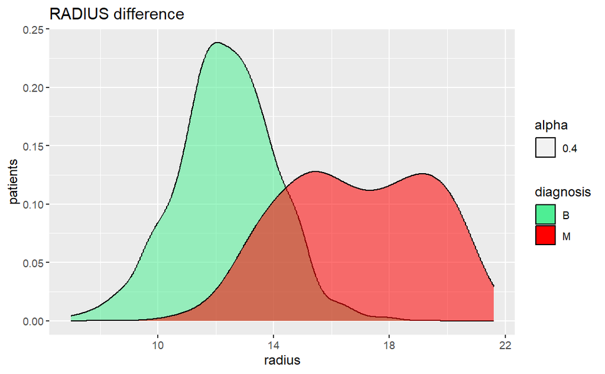

```r
# Radius
ggplot(X) + aes(x=radius_mean, fill=diagnosis, alpha = 0.4) +geom_density()+xlab("radius") + ylab("patients")+ scale_fill_manual(values = c("seagreen2", "red"))+ ggtitle("RADIUS difference")
```

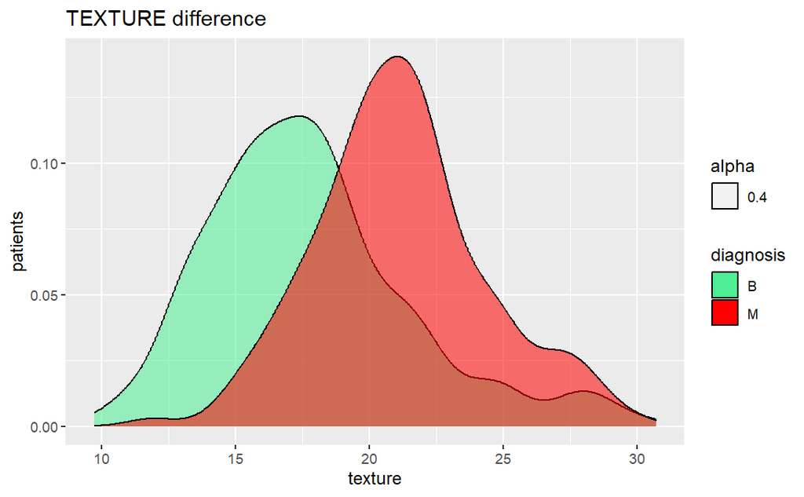

```r
# Texture
ggplot(X) + aes(x=texture_mean, fill=diagnosis, alpha = 0.4) +geom_density()+xlab("texture") + ylab("patients")+ scale_fill_manual(values = c("seagreen2", "red"))+ ggtitle("TEXTURE difference")
```

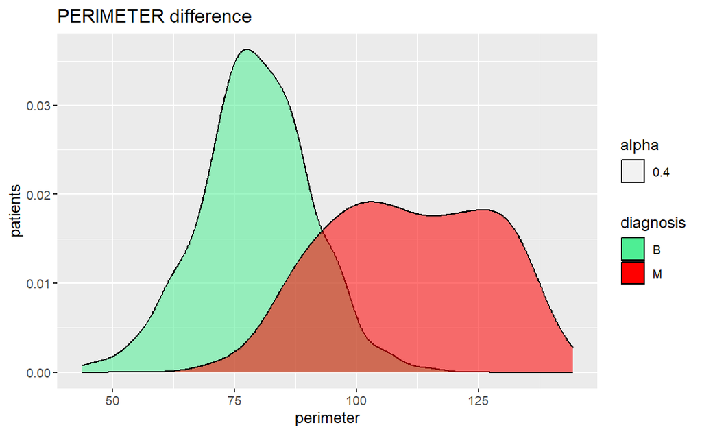

```r
#Perimeter
ggplot(X) + aes(x=perimeter_mean, fill=diagnosis, alpha = 0.4) +geom_density()+xlab("perimeter") + ylab("patients")+ scale_fill_manual(values = c("seagreen2", "red"))+ ggtitle("PERIMETER difference")
```

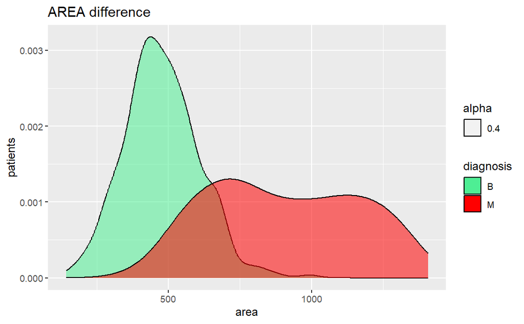

```r
#area
ggplot(X) + aes(x=area_mean, fill=diagnosis, alpha = 0.4) +geom_density()+xlab("area") + ylab("patients")+ scale_fill_manual(values = c("seagreen2", "red"))+ ggtitle("AREA difference")
```

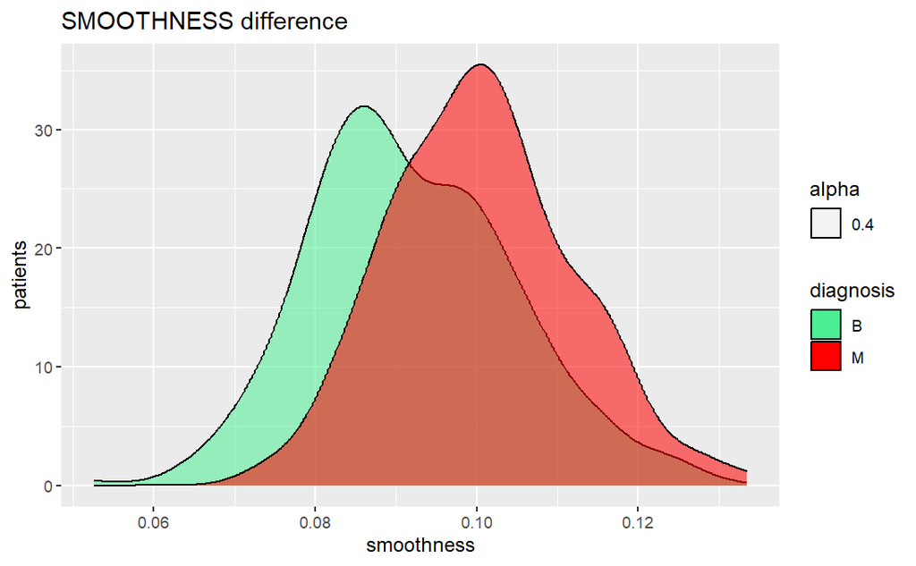

```r
#smoothness
ggplot(X) + aes(x=smoothness_mean, fill=diagnosis, alpha = 0.4) +geom_density()+xlab("smoothness") + ylab("patients")+ scale_fill_manual(values = c("seagreen2", "red"))+ ggtitle("SMOOTHNESS difference")
```

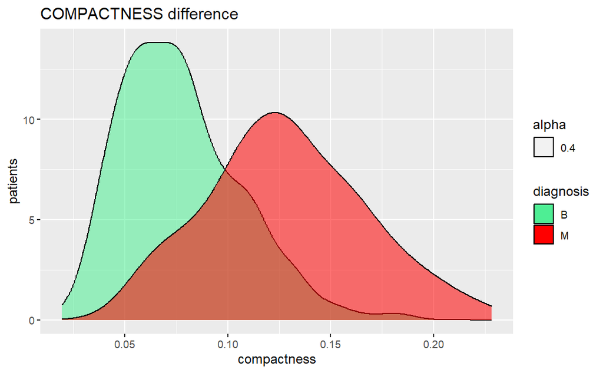

```r
#compactness
ggplot(X) + aes(x=compactness_mean, fill=diagnosis, alpha = 0.4) +geom_density()+xlab("compactness") + ylab("patients")+ scale_fill_manual(values = c("seagreen2", "red"))+ ggtitle("COMPACTNESS difference")
```

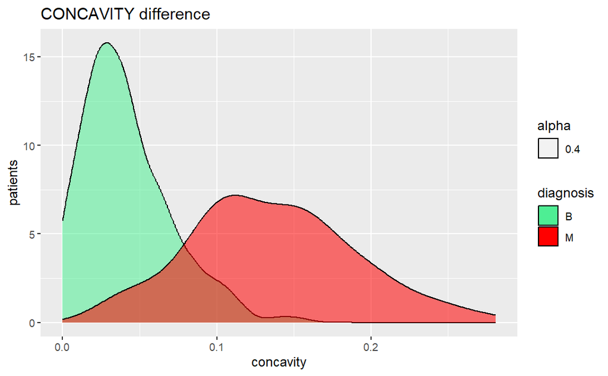

```r
#concavity
ggplot(X) + aes(x=concavity_mean, fill=diagnosis, alpha = 0.4) +geom_density()+xlab("concavity") + ylab("patients")+ scale_fill_manual(values = c("seagreen2", "red"))+ ggtitle("CONCAVITY difference")
```

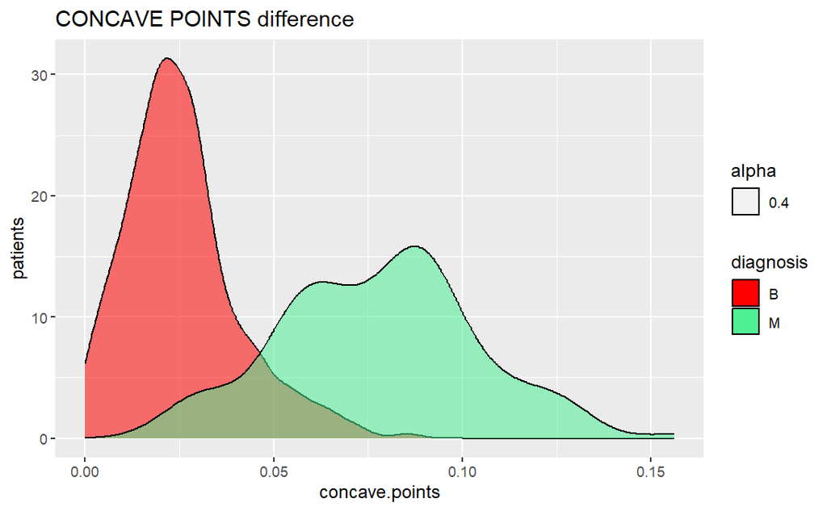

```r
#concave.points
ggplot(X) + aes(x=concave.points_mean, fill=diagnosis, alpha = 0.4) +geom_density()+xlab("concave.points") + ylab("patients")+ scale_fill_manual(values = c("red", "seagreen2"))+ ggtitle("CONCAVE POINTS difference")
```

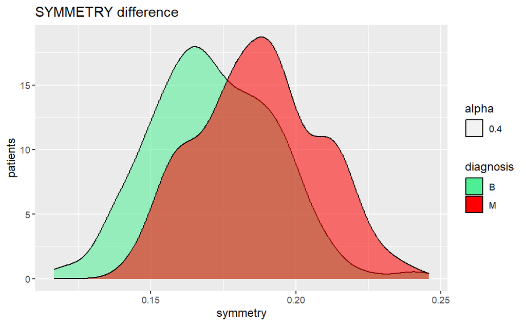

```r
#symmetry
ggplot(X) + aes(x=symmetry_mean, fill=diagnosis, alpha = 0.4) +geom_density()+xlab("symmetry") + ylab("patients")+ scale_fill_manual(values = c("seagreen2", "red"))+ ggtitle("SYMMETRY difference")
```

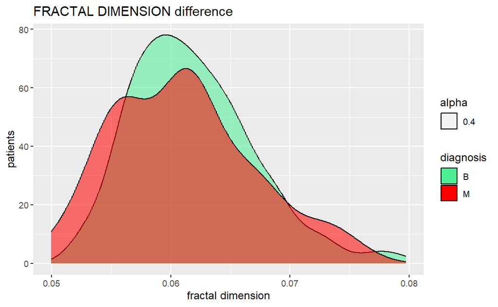

```r
#factal dimension
ggplot(X) + aes(x=fractal_dimension_mean, fill=diagnosis, alpha = 0.4) +geom_density()+xlab("fractal dimension") + ylab("patients")+ scale_fill_manual(values =c("seagreen2", "red"))+ ggtitle("FRACTAL DIMENSION difference")
```

See how most of the variables are distributed differently in relation to the type of tumor that the women have. We can stand out the concave.points, the concavity and the area

**Multiple Scatterplots**

Plot the correlation matrix:

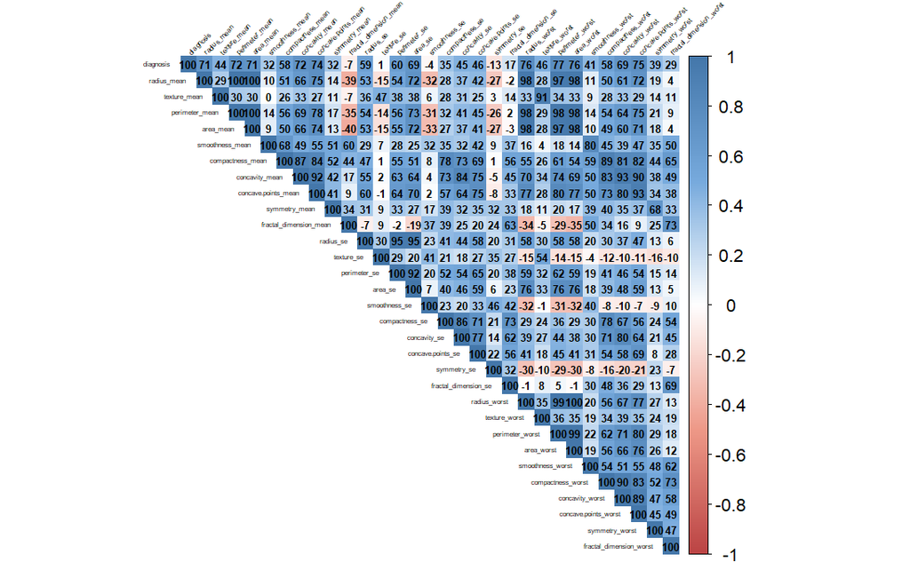

```r
# We make the correlation with different methods in order to obtain exaclty the values that we want
# Firstly , we are going to take into account the diagnosis variable, as we want to classify the data into malignant and benignant tumors, we need to work with variables that are correlated with the variable diagnosis. For make the correlation using diagnosis, the first thing to do is transform the variable into numerical
X$diagnosis = as.numeric(X$diagnosis)

spearman_cor=cor(X, method = "spearman")
col <- colorRampPalette(c("#BB4444", "#EE9988", "#FFFFFF", "#77AADD", "#4477AA"))

corrplot(spearman_cor, method = "color", col = col(200), type = "upper", tl.col = "black", tl.srt = 45, addCoef.col = T, addCoefasPercent = T, tl.cex = 0.3, number.cex = 0.5)
```

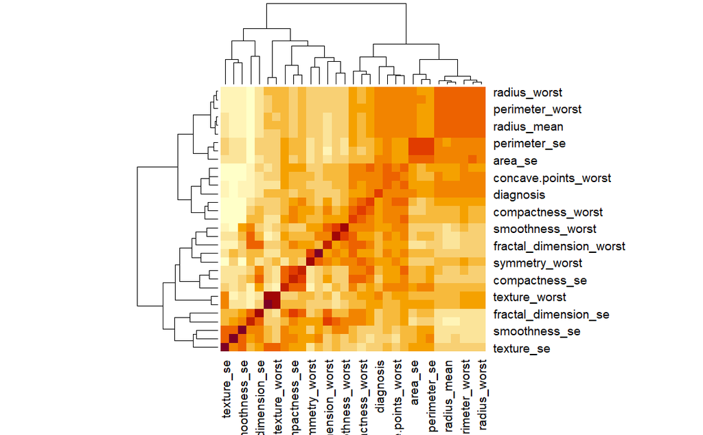

```r
heatmap(cor(X))
```

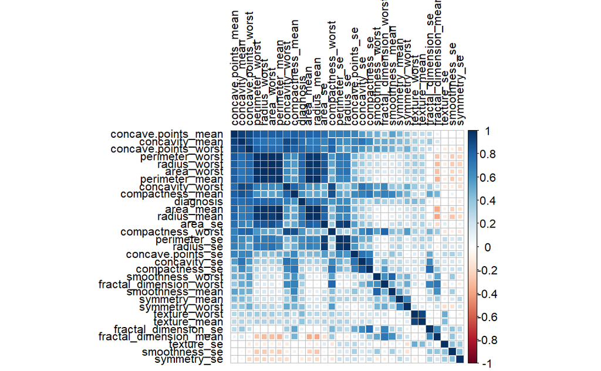

```r
correlations <- cor(X,method="pearson")
corrplot(correlations, number.cex = .9, method = "square",
         hclust.method = "ward", order = "FPC",
         type = "full", tl.cex=0.8,tl.col = "black")
```

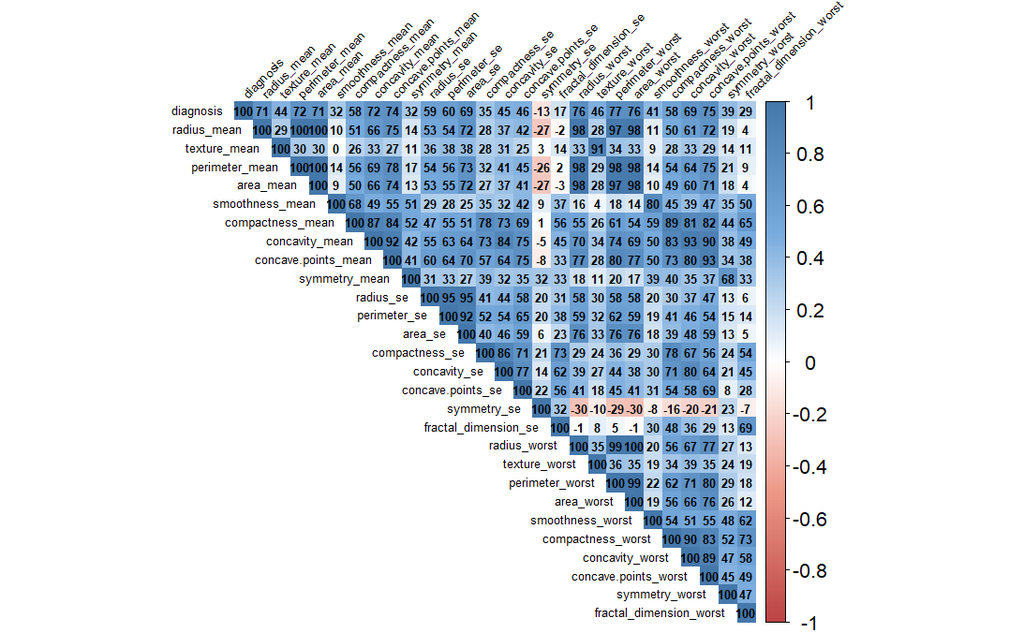

```r
#make again the correlation without the values that are not correlated with diagnosis by both methods(pearson and spearman), those are : fractal_dimension_mean, texture_se and smoothness_se
X = X %>% dplyr :: select ( -fractal_dimension_mean, -texture_se, -smoothness_se)

spearman_cor=cor(X, method = "spearman")
col <- colorRampPalette(c("#BB4444", "#EE9988", "#FFFFFF", "#77AADD", "#4477AA"))

corrplot(spearman_cor, method = "color", col = col(200), type = "upper", tl.col = "black", tl.srt = 45, addCoef.col = T, addCoefasPercent = T, tl.cex = 0.5, number.cex = 0.5)
```

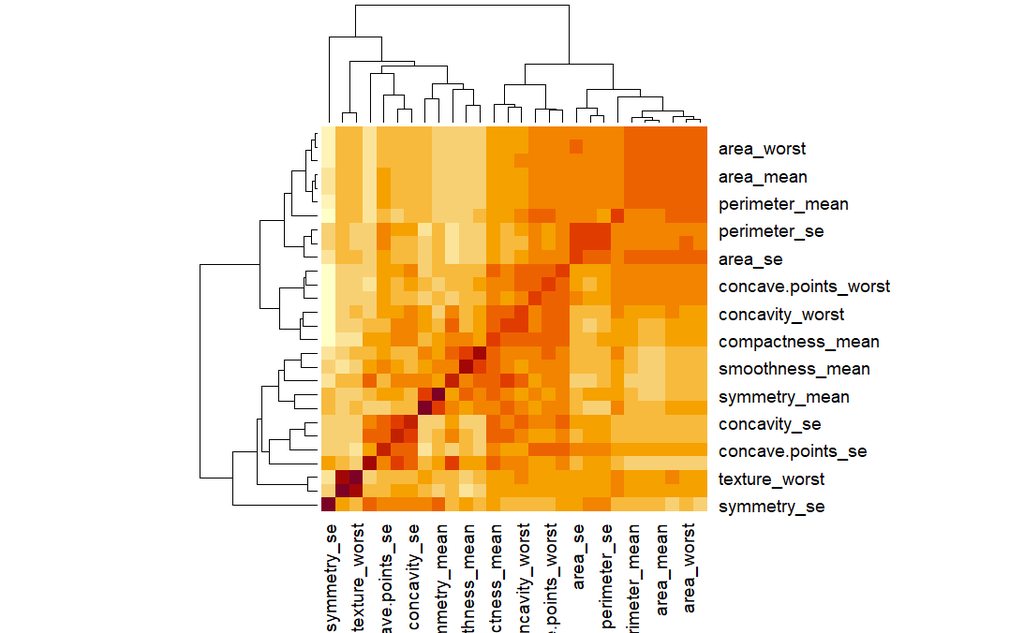

```r
heatmap(cor(X))
```

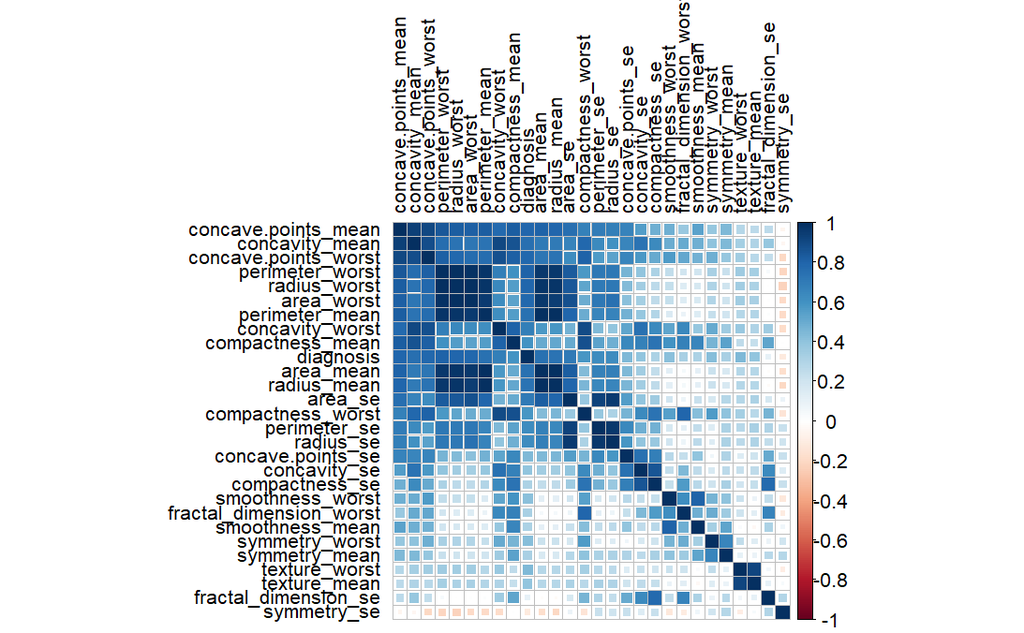

```r
correlations <- cor(X,method="pearson")
corrplot(correlations, number.cex = .9, method = "square",
         hclust.method = "ward", order = "FPC",
         type = "full", tl.cex=0.8,tl.col = "black")
```

```r
NA
NA
```

We can see that most of the variables are high correlated with each other, that’s a good point because means that we can reach a prediction studying them

The highest correlations are between:

Perimeter_mean and radius_worst

area_worst and radius_worst;

texture_mean and texture_worst;

Perimeter_mean and area_worst

Let’s show the plots for some of these highly correlated features. We will use ggplot, showing the scatter plot (in the two dimensions given by the selected features) for the clustered data (grouped by diagnosis)

But first transform the diagnosis variable into factor, save the variable and remove that column from the dataset in order to only work with numerical variables

```r
# Change into character before saving the variable
X$diagnosis = factor(X$diagnosis, levels = c("1","2"), labels = c("B", "M"))

X$diagnosis = as.character(X$diagnosis)

#save it
diagnosis = X$diagnosis
# Remove the diagnosis variable
X = X %>% dplyr :: select ( -diagnosis)
```

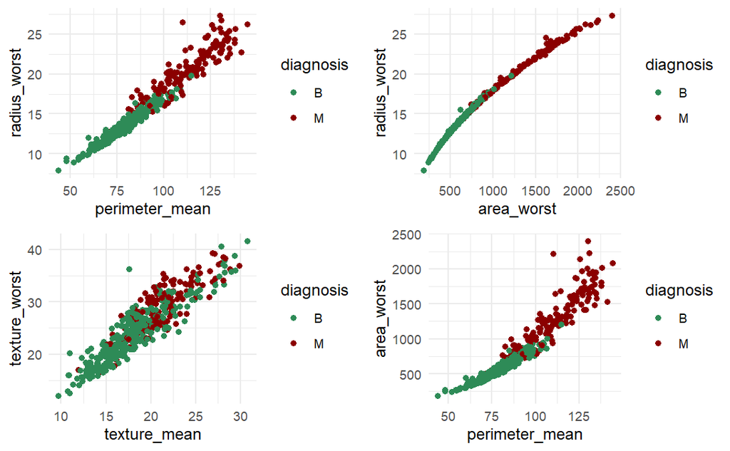

```r
g1 = ggplot(X) + aes(x = perimeter_mean, y = radius_worst, color= diagnosis)+ geom_jitter() + scale_color_manual(values = c("seagreen", "darkred"))+ theme_minimal()
g2 = ggplot(X) + aes(x = area_worst, y = radius_worst, color= diagnosis)+ geom_jitter() + scale_color_manual(values = c("seagreen", "darkred"))+ theme_minimal()
g3 = ggplot(X) + aes(x = texture_mean, y = texture_worst, color= diagnosis)+ geom_jitter() + scale_color_manual(values = c("seagreen", "darkred"))+ theme_minimal()
g4 = ggplot(X) + aes(x = perimeter_mean, y = area_worst, color= diagnosis)+ geom_jitter() + scale_color_manual(values = c("seagreen", "darkred"))+ theme_minimal()

grid.arrange(g1, g2, g3, g4, ncol=2)
```

In this plots we can see the huge correlation between those variables distinguishing by the diagnosis results

Let’s use first the PCA in order to reduce dimensionality

## PCA

```r
pca = prcomp(X, scale=T)
summary(pca)
```

```
Importance of components:
                          PC1    PC2     PC3     PC4     PC5     PC6     PC7     PC8    PC9    PC10    PC11    PC12
Standard deviation     3.6914 2.0500 1.50708 1.33576 1.25500 1.00528 0.81195 0.63740 0.6082 0.50058 0.47756 0.41624
Proportion of Variance 0.5047 0.1557 0.08412 0.06608 0.05833 0.03743 0.02442 0.01505 0.0137 0.00928 0.00845 0.00642
Cumulative Proportion  0.5047 0.6603 0.74445 0.81053 0.86887 0.90630 0.93071 0.94576 0.9595 0.96874 0.97719 0.98360
                          PC13   PC14    PC15    PC16    PC17   PC18    PC19    PC20    PC21    PC22    PC23    PC24
Standard deviation     0.30423 0.2750 0.24270 0.21510 0.20374 0.1803 0.16602 0.14921 0.12025 0.11149 0.09247 0.08887
Proportion of Variance 0.00343 0.0028 0.00218 0.00171 0.00154 0.0012 0.00102 0.00082 0.00054 0.00046 0.00032 0.00029
Cumulative Proportion  0.98703 0.9898 0.99202 0.99373 0.99527 0.9965 0.99749 0.99832 0.99885 0.99931 0.99963 0.99992
                          PC25    PC26    PC27
Standard deviation     0.03789 0.02385 0.01048
Proportion of Variance 0.00005 0.00002 0.00000
Cumulative Proportion  0.99997 1.00000 1.00000
```

Let’s plot how many components we need to explain a good portion of the variability:

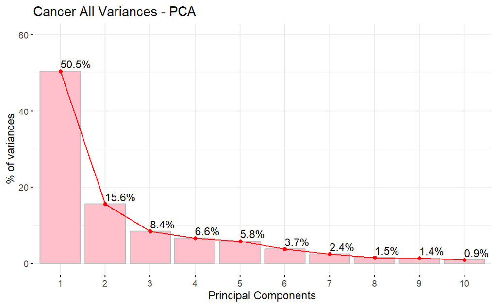

```r
fviz_eig(pca, addlabels=TRUE, ylim=c(0,60), geom = c("bar", "line"), barfill = "pink", barcolor="grey",linecolor = "red", ncp=10)+
labs(title = "Cancer All Variances - PCA",
         x = "Principal Components", y = "% of variances")
```

On this graph we see the % of variability explained by each component

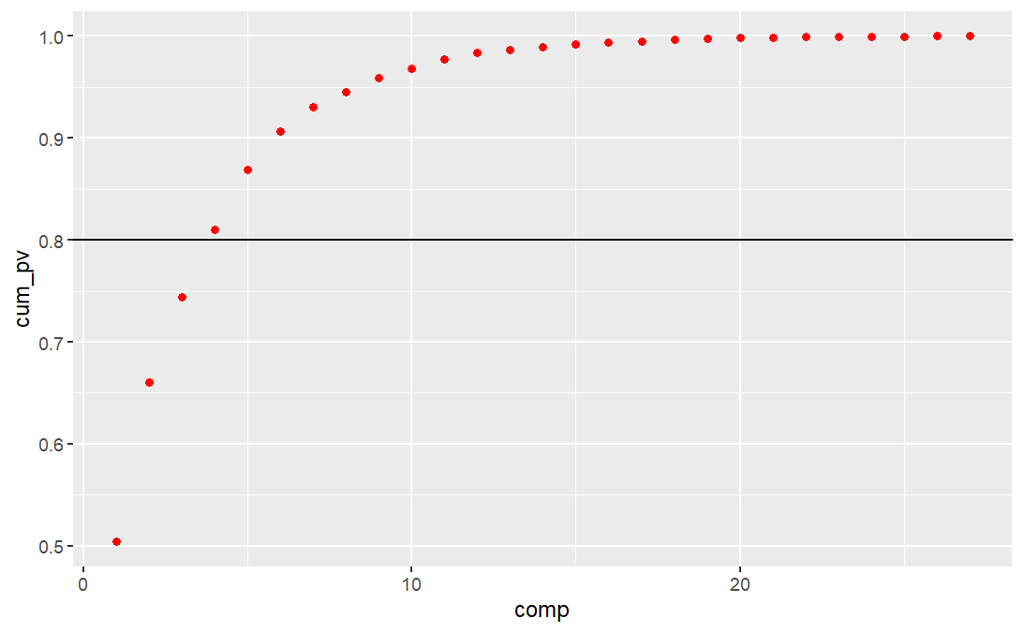

```r
# Calculate the proportion of variance explained
pca_data_var<- pca$sdev^2
pv_data<-pca_data_var/sum(pca_data_var)
cum_pv<- cumsum(pv_data)
pv_table<- tibble(comp= seq(1:ncol(X)),pv_data,cum_pv)

#Let's plot the graph

ggplot(pv_table,aes(x=comp,y=cum_pv))+ geom_point(col= "red")+ geom_abline(intercept = 0.80,slope = 0)
```

With the help graph we can see that 4 components are sufficient for explaining more than 80% of the data.

Make a plot showing the correlation between variables and PCA

```r
#Get PCA variables
all_var <- get_pca_var(pca)
all_var
```

```
Principal Component Analysis Results for variables
 ===================================================
  Name       Description
1 "$coord"   "Coordinates for the variables"
2 "$cor"     "Correlations between variables and dimensions"
3 "$cos2"    "Cos2 for the variables"
4 "$contrib" "contributions of the variables"
```

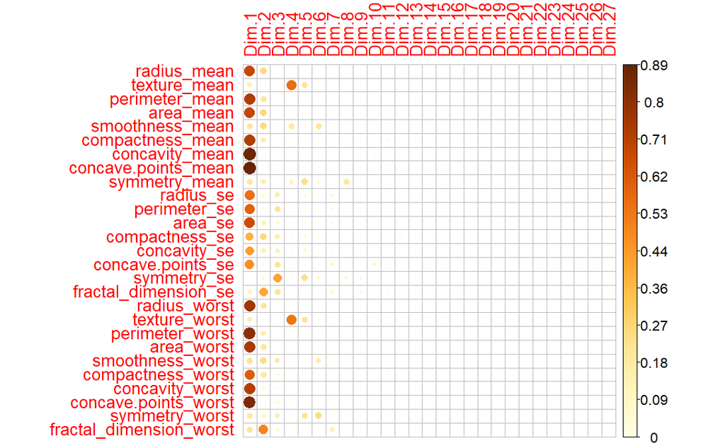

```r
# Plot showing the relation
corrplot(all_var$cos2, is.corr=FALSE)
```

On this plot we can see how most of the variability is explained when we are in dimension 4 , that is, with 4 PCA’s. As we have calculated previously, 4 components were the ones that explain more than 80% of variability, so we are going to plot those components, analyze them and seeing their contributions

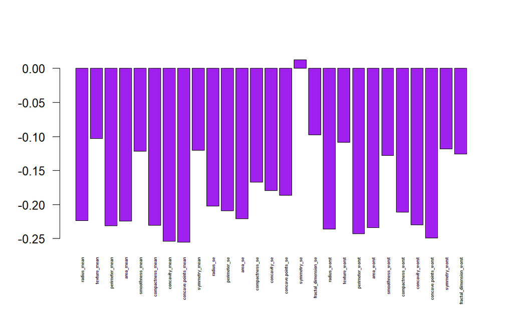

```r
barplot(pca$rotation[,1], las=2, col="purple", cex.names = 0.35)
```

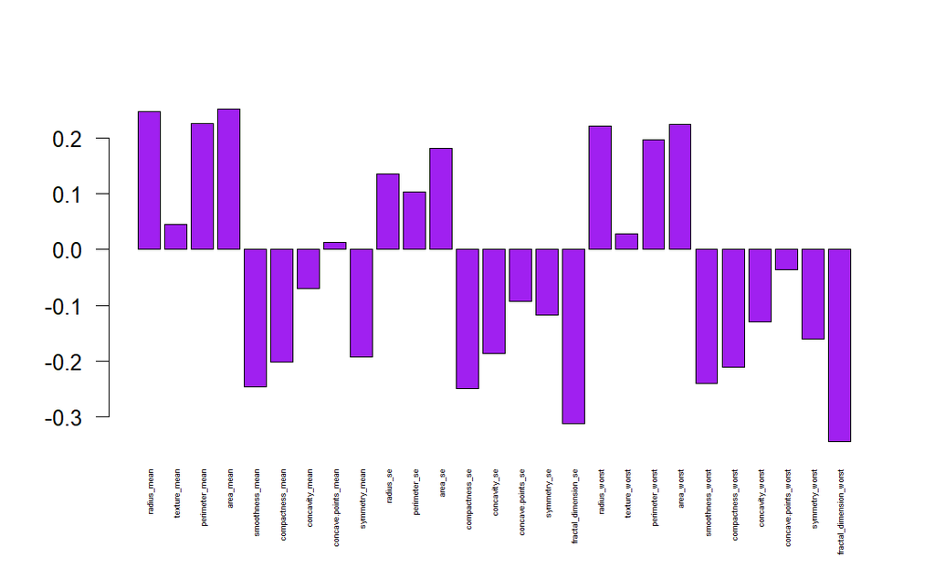

```r
barplot(pca$rotation[,2], las=2, col="purple", cex.names = 0.35)
```

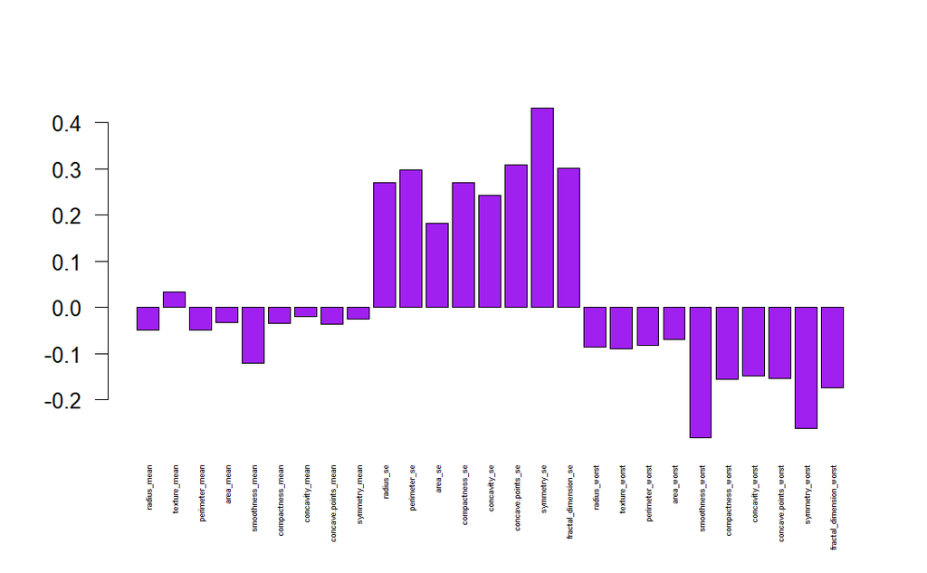

```r
barplot(pca$rotation[,3], las=2, col="purple", cex.names = 0.35)
```

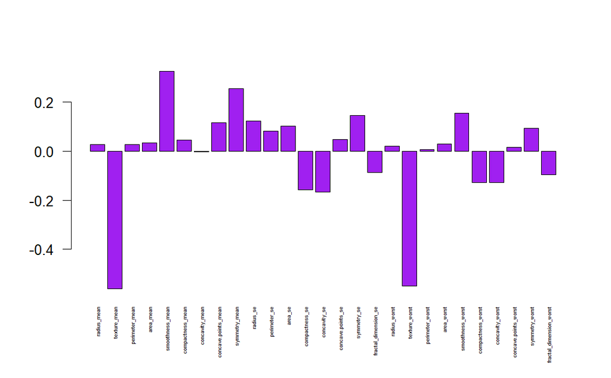

```r
barplot(pca$rotation[,4], las=2, col="purple", cex.names = 0.35)
```

Analyzing the components: Contributions of the variables , for that we are going to use the function fviz_contrib : This function can be used to visualize the contribution of rows/columns from the results of Principal Component Analysis (PCA),

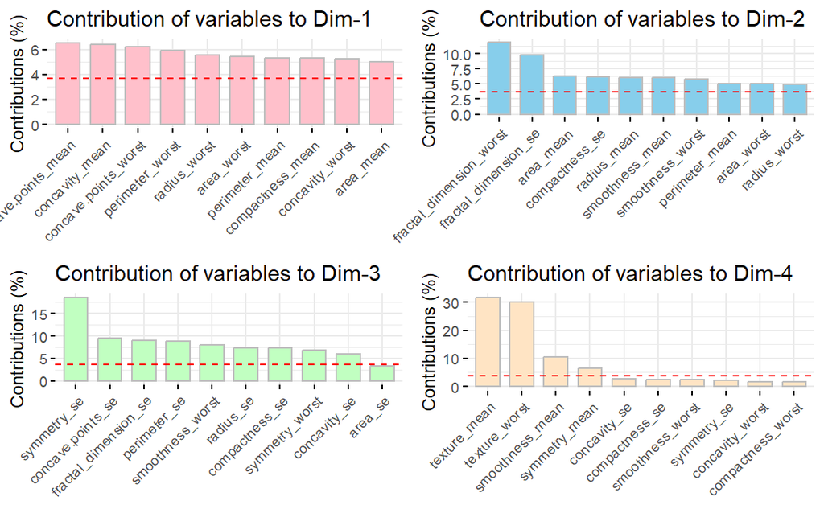

```r
p1 <- fviz_contrib(pca, choice="var", axes=1, fill="pink", color="grey", top=10)
p2 <- fviz_contrib(pca, choice="var", axes=2, fill="skyblue", color="grey", top=10)
p3 <- fviz_contrib(pca, choice="var", axes=3, fill="darkseagreen1", color="grey", top=10)
p4 <- fviz_contrib(pca, choice="var", axes=4, fill="bisque", color="grey", top=10)
grid.arrange(p1,p2,p3,p4,ncol=2)
```

On this plot we can see the top 10 variables that most contribute to each of our principal components,

Analyze of the components:

From all this different plots showing the characteristics of the PCA, we see that on the first component most of the variables have huge contributions excepting one: symmetry_se. The second has contributions from almost all the variables except from concave.points_mean, texture_worst and concave.points_worst. The third component has a huge contribution from all the standard error variables(especially the symmetry_se) , also has some contributions from the worst ones and very few ones from the means. Finally we can see how the fourth PCA has a strong contribution from 2 variables and very few contributions from the others and, casually, this 2 variables are of texture(texture_mean and texture_worst)

Lets now make a plot with the 2 first principal components, filling by diagnosis

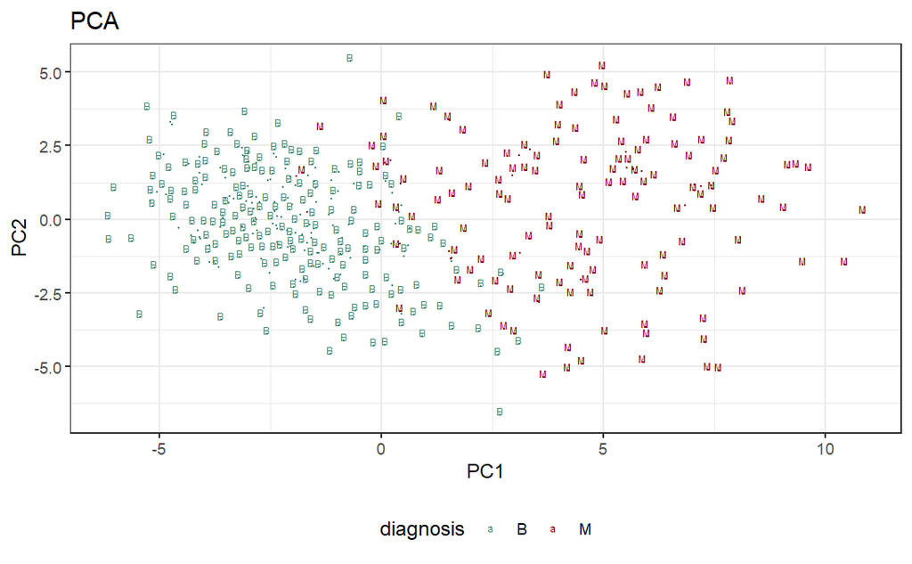

```r
data.frame(z1=-pca$x[,1],z2=pca$x[,2]) %>%
  ggplot(aes(z1,z2,label=diagnosis, color = diagnosis)) + geom_point(size=0.2) +
  labs(title="PCA", x="PC1", y="PC2") +
  theme_bw() + scale_color_manual(values =c("aquamarine4", "darkred"))+theme(legend.position="bottom") + geom_text(size=2, hjust=0.6, vjust=0, check_overlap = TRUE)
```

```r
NA
NA
```

Now, lets make the same but with the first 3 Principal components in 3D

```r
pc1 <- pca$x[, 1]
pc2 <- pca$x[, 2]
pc3 <- pca$x[, 3]
#for this plot Im going to create a variable substituing M-> red, B->green to distinguish on the 3d plot between malignant and benignant tumors
c_diag = diagnosis
c_diag = gsub("M", "darkred", c_diag)
c_diag = gsub("B", "aquamarine4", c_diag)
plot3d(pc1, pc2, pc3, type = "p", size = 10, col = c_diag, xlab = "PC1", ylab = "PC2", zlab = "PC3")
```

[output not shown]

Remember that 3 components explain almost the 75% of the variability

## Factor Analysis

Factor Analysis is an analytical tool that produces models that will reduce dimension (reduce columns). It creates linear combinations of factors in order to find which are the most important, because they ‘capture’ most of the variance of the dataset.

We make first the parallel analysis, this is one way to determine the number of factors in a data matrix that consist on examine the “scree” plot of the successive eigenvalues

```
Parallel analysis suggests that the number of factors =  5  and the number of components =  NA
```

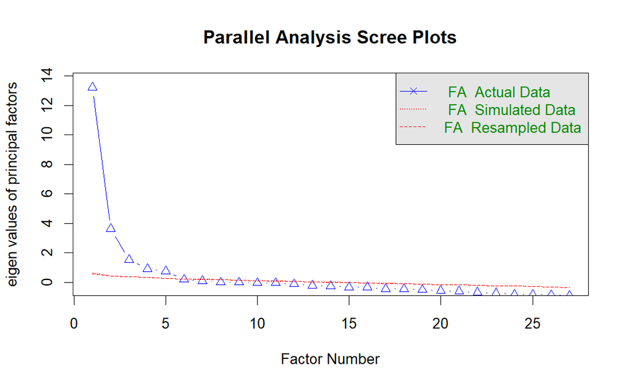

```r
nafactor<-fa.parallel(X,fm = "ml",fa = "fa")
```

```r
nafactor$fa.values
```

```
 [1] 13.225193370  3.620100968  1.536125181  0.917560957  0.746979994  0.187693512  0.096609680 -0.002286765
 [9] -0.004819539 -0.042630873 -0.049307422 -0.129390570 -0.213424345 -0.250524918 -0.325163399 -0.341442305
[17] -0.454439694 -0.460477820 -0.513433426 -0.575796742 -0.617378821 -0.697805324 -0.723751774 -0.819815749
[25] -0.828945725 -0.855189643 -0.918984667
```

Here we see the values of the factors of the parallel analysis , we know that the good factors are the ones that are greater than one, so let’s compute them:

```r
sum(nafactor$fa.values>1)
```

```
[1] 3
```

so we obtain that 3 factors are good

**Run the Factor Analysis**

Four factors will be used since 3 are greater than 1 and there is one very near to 1, and let’s also use the oblimin rotation because of the multicollinearity of the variables.nafactor$fa.values

We will use the function fa(performs factor analysis on a given data set or correlation matrix and returns an object that contains information about the factor analysis results) with the factor method “ols” that it minimizes the entire residual matrix using an OLS procedure(minimize the sum of the squared residuals) using the empirical first derivative.

```r
fa1<-fa(X,nfactors = 4,rotate = "oblimin", scores = "regression", fm = "ols")
print(fa1)
```

```
Factor Analysis using method =  ols
Call: fa(r = X, nfactors = 4, rotate = "oblimin", scores = "regression",
    fm = "ols")
Standardized loadings (pattern matrix) based upon correlation matrix
```

|  | 1 | 2 | 3 | 4 | h2 | u2 | com |
| --- | --- | --- | --- | --- | --- | --- | --- |
| radius_mean | 0.98 | 0.00 | -0.07 | 0.03 | 0.9436053 | 0.056394708 | 1.013775 |
| texture_mean | 0.02 | -0.12 | 0.08 | 0.92 | 0.8328669 | 0.167133138 | 1.047362 |
| perimeter_mean | 0.96 | 0.04 | -0.05 | 0.04 | 0.9468501 | 0.053149919 | 1.011812 |
| area_mean | 0.99 | -0.03 | -0.05 | 0.03 | 0.9568674 | 0.043132601 | 1.009073 |
| smoothness_mean | 0.03 | 0.67 | 0.12 | -0.27 | 0.4971691 | 0.502830914 | 1.389328 |
| compactness_mean | 0.25 | 0.71 | 0.28 | -0.01 | 0.9128155 | 0.087184515 | 1.584908 |
| concavity_mean | 0.50 | 0.51 | 0.23 | 0.07 | 0.8994459 | 0.100554101 | 2.407515 |
| concave.points_mean | 0.69 | 0.42 | 0.15 | -0.06 | 0.9135183 | 0.086481737 | 1.765806 |
| symmetry_mean | 0.06 | 0.46 | 0.19 | -0.11 | 0.3132826 | 0.686717386 | 1.514015 |
| radius_se | 0.69 | -0.18 | 0.48 | 0.00 | 0.7947696 | 0.205230391 | 1.946738 |

[output cut: 17 more lines]

```
                      [,1] [,2] [,3] [,4]
SS loadings           9.40 5.91 3.55 2.11
Proportion Var        0.35 0.22 0.13 0.08
Cumulative Var        0.35 0.57 0.70 0.78
Proportion Explained  0.45 0.28 0.17 0.10
Cumulative Proportion 0.45 0.73 0.90 1.00

 With factor correlations of
     [,1] [,2] [,3] [,4]
[1,] 1.00 0.31 0.27 0.31
[2,] 0.31 1.00 0.32 0.24
[3,] 0.27 0.32 1.00 0.15
[4,] 0.31 0.24 0.15 1.00

Mean item complexity =  1.4
Test of the hypothesis that 4 factors are sufficient.

df null model =  351  with the objective function =  67.25 with Chi Square =  31348.97
df of  the model are 249  and the objective function was  26.64

The root mean square of the residuals (RMSR) is  0.06
The df corrected root mean square of the residuals is  0.07

The harmonic n.obs is  477 with the empirical chi square  1170.05  with prob <  4.4e-119
The total n.obs was  477  with Likelihood Chi Square =  12346.1  with prob <  0

Tucker Lewis Index of factoring reliability =  0.447
RMSEA index =  0.319  and the 90 % confidence intervals are  0.315 0.324
BIC =  10810.39
Fit based upon off diagonal values = 0.99
```

**SS loadings**: if the number is grater than one is a good factor. Otherwise that factor doesn’t explain well your data . We see that the 4 factors are good ones.

The four factors explain 78% of the variance: factor 1 for 35%, factor 2 for 23%, factor 3 for 13%, and factor 4 for 8%, also factors are poorly correlated let’s use the orthogonal rotation (varimax)

This analysis will be done with the factor method “minchi”, this method minimizes the sample size weighted chi square when treating pairwise correlations with different number of subjects per pair.

```r
fa2<-fa(X,nfactors = 4,rotate = "varimax", scores = "regression", fm="minchi")
print(fa2)
```

```
Factor Analysis using method =  minchi
Call: fa(r = X, nfactors = 4, rotate = "varimax", scores = "regression",
    fm = "minchi")
Standardized loadings (pattern matrix) based upon correlation matrix
```

|  | MC1 | MC4 | MC2 | MC3 | h2 | u2 | com |
| --- | --- | --- | --- | --- | --- | --- | --- |
| radius_mean | 0.96 | 0.08 | 0.13 | -0.12 | 0.9532027 | 0.046797337 | 1.084002 |
| texture_mean | 0.30 | 0.28 | -0.04 | -0.02 | 0.1720079 | 0.827992127 | 2.036745 |
| perimeter_mean | 0.95 | 0.12 | 0.17 | -0.11 | 0.9560392 | 0.043960788 | 1.122431 |
| area_mean | 0.97 | 0.07 | 0.13 | -0.08 | 0.9605896 | 0.039410397 | 1.059360 |
| smoothness_mean | 0.04 | 0.09 | 0.79 | 0.15 | 0.6646971 | 0.335302856 | 1.105344 |
| compactness_mean | 0.40 | 0.58 | 0.64 | 0.03 | 0.9133007 | 0.086699341 | 2.667625 |
| concavity_mean | 0.61 | 0.47 | 0.58 | 0.03 | 0.9306597 | 0.069340349 | 2.869163 |
| concave.points_mean | 0.73 | 0.24 | 0.62 | 0.07 | 0.9774707 | 0.022529310 | 2.194511 |
| symmetry_mean | 0.12 | 0.19 | 0.51 | 0.18 | 0.3444231 | 0.655576902 | 1.700115 |
| radius_se | 0.77 | 0.16 | 0.12 | 0.46 | 0.8359692 | 0.164030809 | 1.788418 |

[output cut: 17 more lines]

```
                       MC1  MC4  MC2  MC3
SS loadings           9.73 4.54 4.31 1.84
Proportion Var        0.36 0.17 0.16 0.07
Cumulative Var        0.36 0.53 0.69 0.76
Proportion Explained  0.48 0.22 0.21 0.09
Cumulative Proportion 0.48 0.70 0.91 1.00

Mean item complexity =  1.9
Test of the hypothesis that 4 factors are sufficient.

df null model =  351  with the objective function =  67.25 with Chi Square =  31348.97
df of  the model are 249  and the objective function was  24.99

The root mean square of the residuals (RMSR) is  0.06
The df corrected root mean square of the residuals is  0.08

The harmonic n.obs is  477 with the empirical chi square  1407.85  with prob <  8.2e-161
The total n.obs was  477  with Likelihood Chi Square =  11581.32  with prob <  0

Tucker Lewis Index of factoring reliability =  0.482
RMSEA index =  0.309  and the 90 % confidence intervals are  0.304 0.314
BIC =  10045.61
Fit based upon off diagonal values = 0.98
Measures of factor score adequacy
                                                   MC1  MC4  MC2  MC3
Correlation of (regression) scores with factors   1.00 0.96 0.97 0.96
Multiple R square of scores with factors          0.99 0.93 0.95 0.92
Minimum correlation of possible factor scores     0.99 0.86 0.89 0.84
```

The factors explain almost the same variability with the method before, the root mean square of the residuals (RMSR) is 0.06 which is good, also the root mean square error approximation (RMSEA index) = 0.309 and the 90 % confidence intervals are 0.305 0.314. We can see know how the correlation has increased a lot.

### Interpretation

```r
par(mfrow=c(3,1))
barplot(fa2$loadings[,1], las=2, col="purple2", ylim = c(-1, 1), cex.names = 0.6 )
barplot(fa2$loadings[,2], las=2, col="purple2", ylim = c(-1, 1), cex.names = 0.6)
```

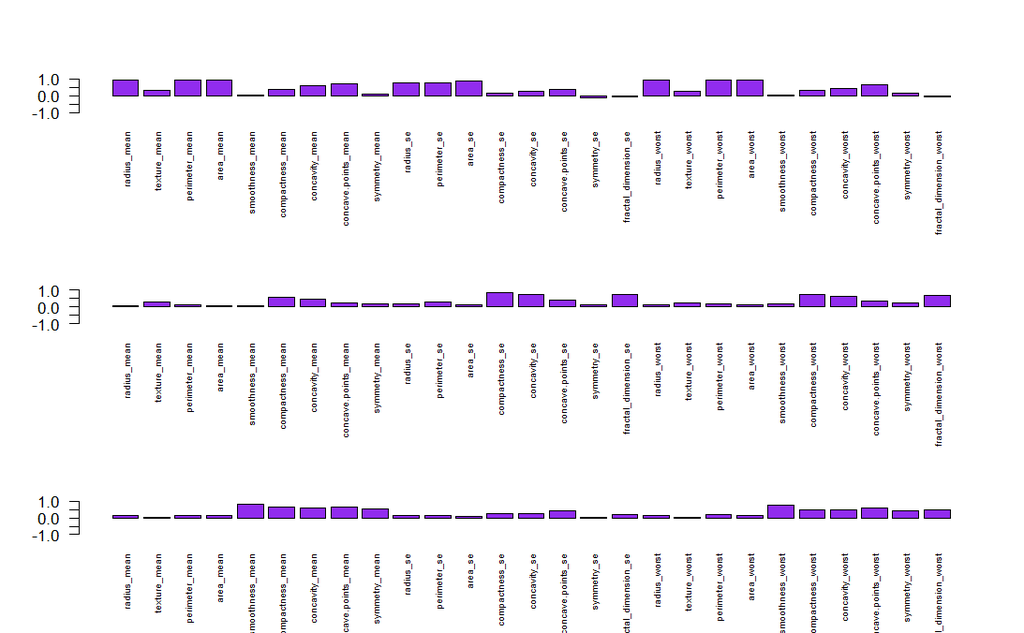

```r
barplot(fa2$loadings[,3], las=2, col="purple2", ylim = c(-1, 1), cex.names = 0.6)
```

[figure not shown]

```r
barplot(fa2$loadings[,4], las=2, col="purple2", ylim = c(-1, 1), cex.names = 0.6)
```

[output not shown]

```r
NA
NA
NA
NA
NA
```

In this barplots we can see the contribution of each variable to each cluster, we can make a diagram for seeing the variables that contributes the most to each cluster

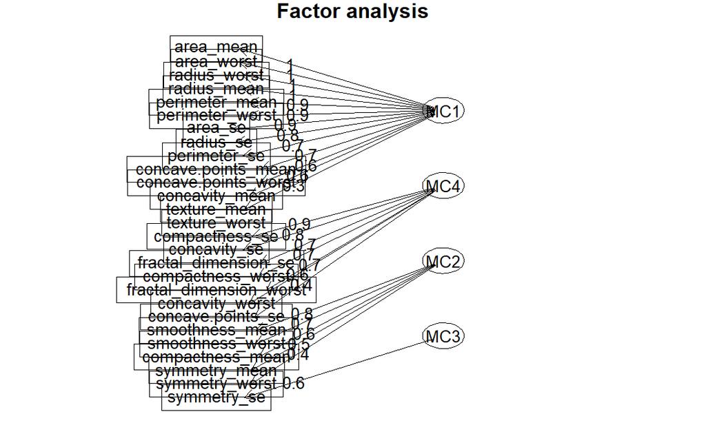

```r
fa.diagram(fa2, rsize = 0.97,main = "Factor analysis", digits=0.5, cex = 0.5 )
```

Conclusion of FA

Using Factor Analysis we can reduce the dimension of the data into 4 factors that explain almost the 80% of the variability, those factors have contributions from the variables of the data, and from the previews plots we can explain the contribution of each variable into each factor , the variables that have more influence in each factors we can see it perfectly on the diagram and are(in descendant contribution order):

F1 (MC1) = area_mean, area_worst, radius_worst, radius_mean, perimeter_mean, perimeter_worst, area_se, radius_se, perimeter_se, concave.points_mean, concave.points_worst, texture_mean, texture_worst

F2 (MC4) = compactness_se, concavity_se, fractal_dimension_se, compactness_worst, fractal_dimension_worst, concavity_worst, concave.points_se

F3(MC2) = smoothness_mean, smoothness_worst, compactness_mean, symmetry_mean, symmetry_worst

F4(MC3) = symmetry_se

**Regression analysis using the factor scores as the independent variable**

```r
#Let's leave the interpretation of the factors and their current names as they are right now and combine the dependent variable and the factor scores into a dataset.
#Create a variable that names M->0, B->1 and transform into numerical in order to make teh regression analysis
f_diag = diagnosis
f_diag = gsub("M", 0, f_diag)
f_diag = gsub("B", 1, f_diag)
f_diag = as.numeric(f_diag)
regression_data<-as.data.frame(cbind(f_diag,fa2$scores))
names(regression_data)<-c("diagnosis","F1","F2","F3","F4")
head(regression_data,10)
```

|  | diagnosis | F1 | F2 | F3 | F4 |
| --- | --- | --- | --- | --- | --- |
| 2 | 0 | 2.45504006 | -0.88131638 | -0.8206594 | -0.9395566 |
| 3 | 0 | 1.89182743 | -0.05369955 | 1.8532669 | 1.1512817 |
| 5 | 0 | 2.20754942 | -0.14510625 | 0.4421253 | 1.9478818 |
| 6 | 0 | -0.79033507 | 0.85994937 | 2.7834037 | -0.3456189 |
| 7 | 0 | 1.70586087 | -0.56969811 | 0.1788999 | -1.4835016 |
| 8 | 0 | -0.04623991 | 0.82457005 | 1.0421637 | 0.3324623 |
| 9 | 0 | -0.77056225 | 0.81640348 | 3.2588086 | -0.4181878 |
| 11 | 0 | 0.95230037 | -0.42272360 | -1.2961427 | -0.9928605 |
| 12 | 0 | 0.83535247 | 1.38323348 | -0.1497227 | -1.0701469 |
| 14 | 0 | 0.54647836 | 0.34993340 | -0.3671358 | 1.0889821 |

```r
NA
NA
NA
NA
```

Divide the data into training and test sets before performing any analysis.

```r
set.seed(122)
#use 80% of dataset as training set and 20% as test set
sample <- sample(c(TRUE, FALSE), nrow(regression_data), replace=TRUE, prob=c(0.8,0.2))
train.data <- regression_data[sample, ]
test.data <- regression_data[!sample, ]
```

Investigate trends:

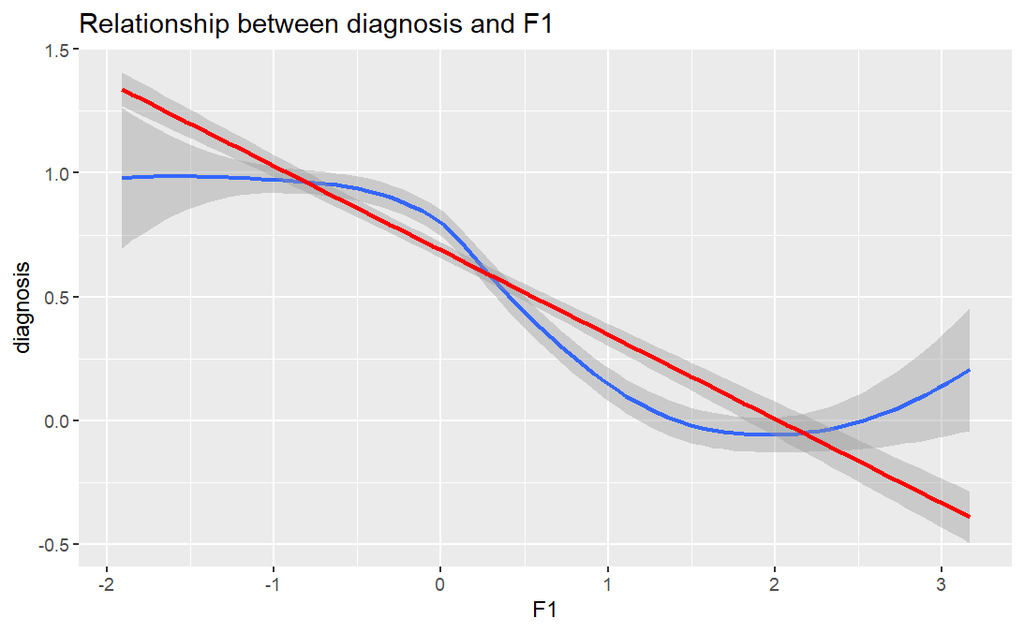

```r
ggplot(train.data,aes(y=diagnosis,x=F1))+
  geom_smooth(method="loess")+
  geom_smooth(method = "lm",col="red")+
  ggtitle("Relationship between diagnosis and F1")
```

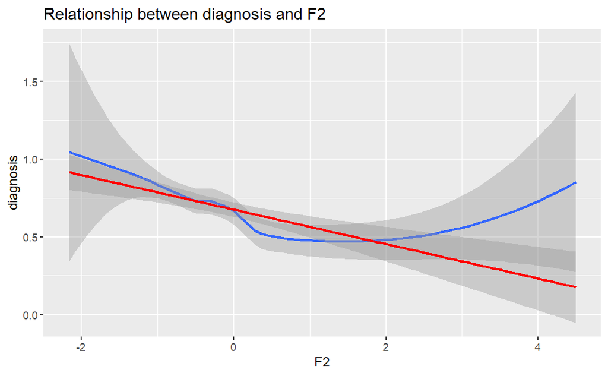

```r
ggplot(train.data,aes(y=diagnosis,x=F2))+
  geom_smooth(method="loess")+
  geom_smooth(method = "lm",col="red")+
  ggtitle("Relationship between diagnosis and F2")
```

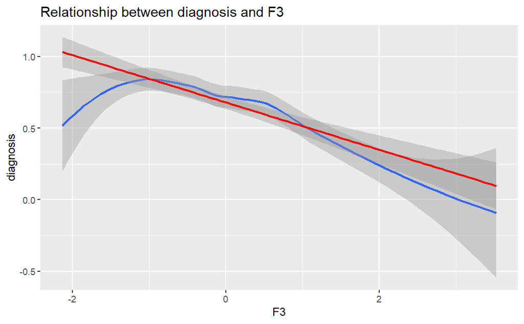

```r
ggplot(train.data,aes(y=diagnosis,x=F3))+
  geom_smooth(method="loess")+
  geom_smooth(method = "lm",col="red")+
  ggtitle("Relationship between diagnosis and F3")
```

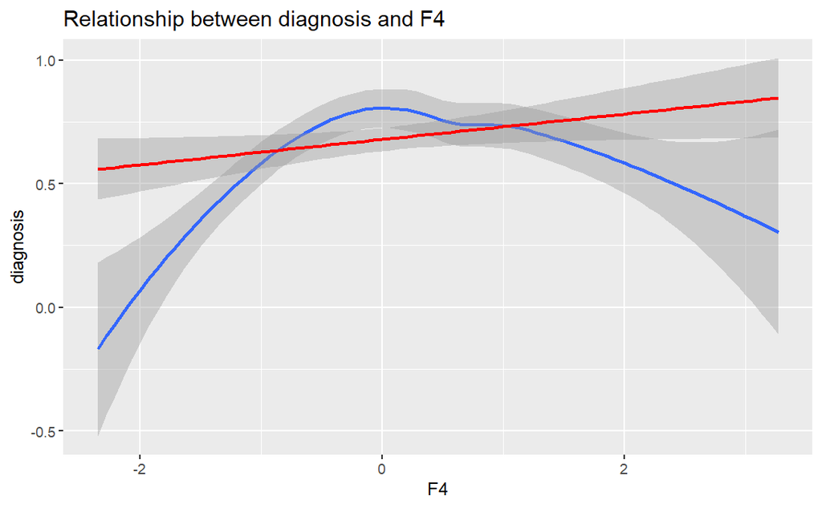

```r
ggplot(train.data,aes(y=diagnosis,x=F4))+
  geom_smooth(method="loess")+
  geom_smooth(method = "lm",col="red")+
  ggtitle("Relationship between diagnosis and F4")
```

We can see a good relation between the factors and the diagnosis in at least the 3 first factors

## Clustering

We initially select 2 clusters, as we want to predict if the patient’s tumor is benignant or malignant

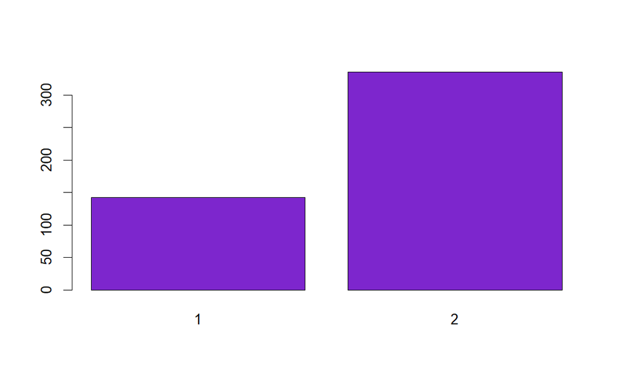

```r
# the best cluster is the one that give the fewer distances to the centroids
k = 2
fit = kmeans(scale(X), centers=k, nstart=1000)
groups = fit$cluster
barplot(table(groups), col="purple3")
```

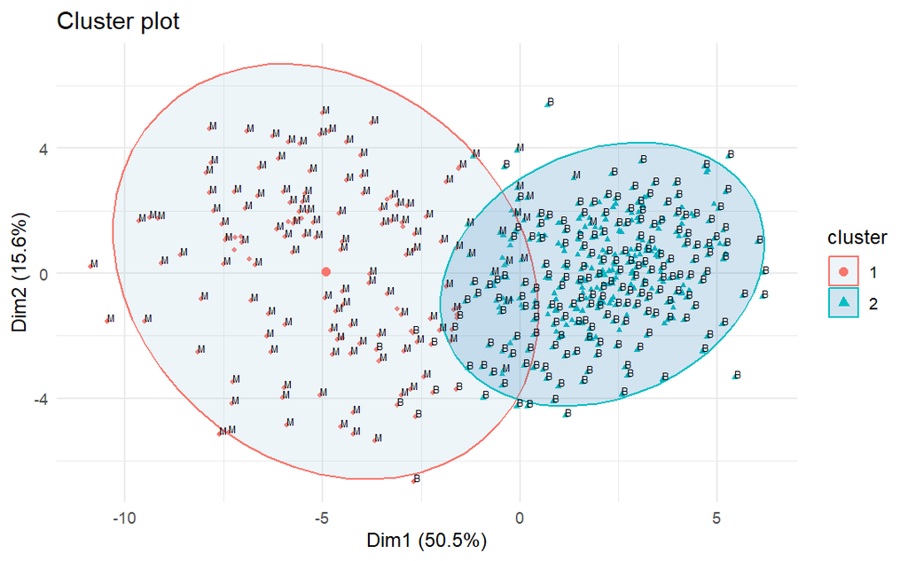

```r
# clusplot
fviz_cluster(fit, data = X, geom = c("point"),ellipse.type = 'norm', pointsize=1)+
  theme_minimal()+geom_text(label=diagnosis,hjust=0, vjust=0,size=2,check_overlap = T)+scale_fill_brewer(palette="Paired")
```

```r
NA
NA
NA
NA
```

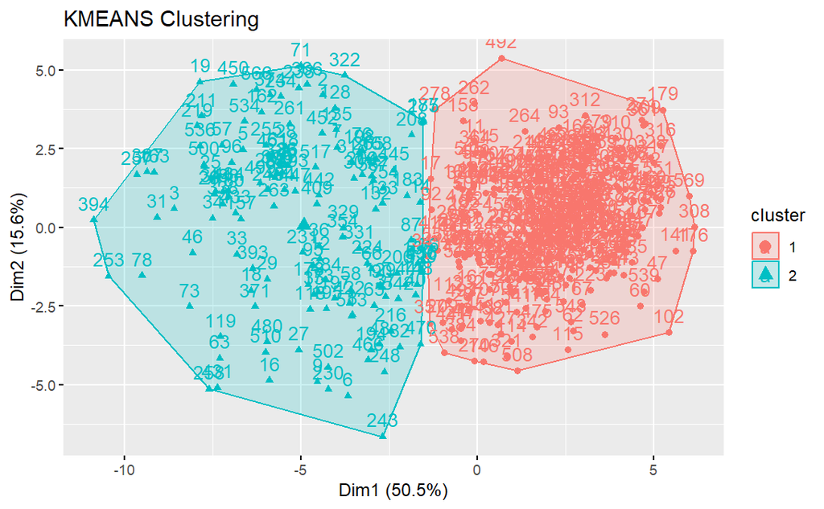

```r
t.kmeans <- eclust(X, "kmeans", stand=TRUE, k=2)
```

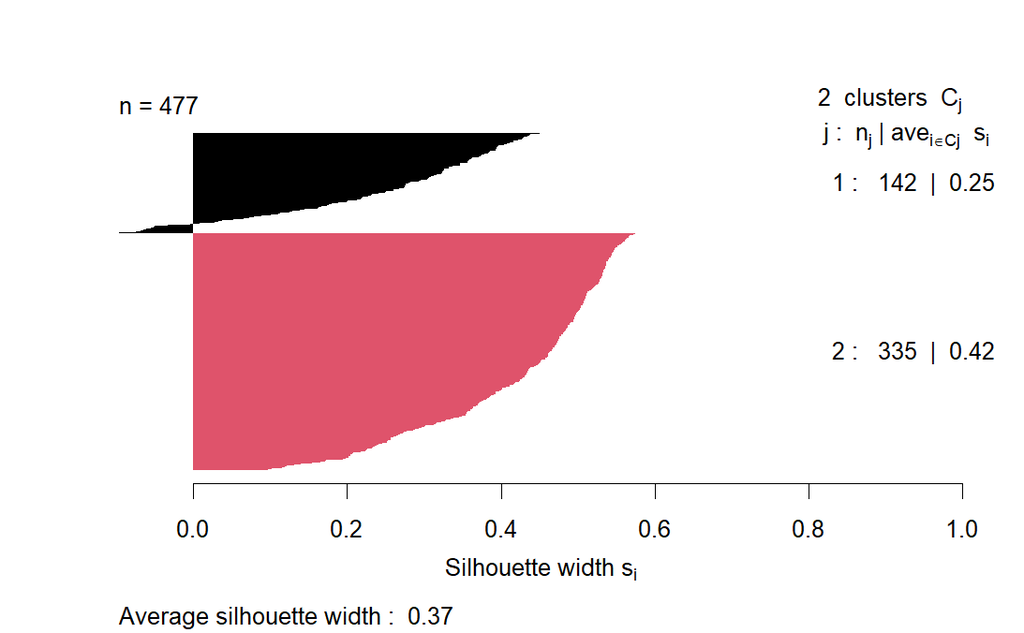

```r
d <- dist(scale(X), method="euclidean")
sil = silhouette(groups, d)
plot(sil, col=1:2, main="", border=NA)
```

```r
summary(sil)
```

```
Silhouette of 477 units in 2 clusters from silhouette.default(x = groups, dist = d) :
 Cluster sizes and average silhouette widths:
      142       335
0.2486666 0.4239720
Individual silhouette widths:
    Min.  1st Qu.   Median     Mean  3rd Qu.     Max.
-0.09617  0.27463  0.40112  0.37178  0.49564  0.57472
```

|  | cluster | size | ave.sil.width |
| --- | --- | --- | --- |
| 1 | 1 | 335 | 0.42 |
| 2 | 2 | 142 | 0.25 |

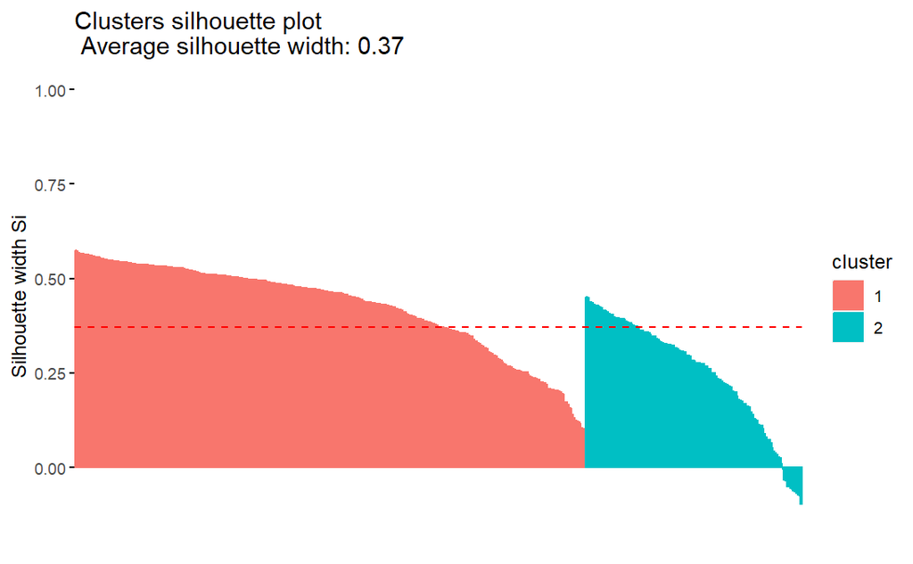

```r
# the same with factoextra
fviz_silhouette(t.kmeans)
```

### Number of clusters by PAM

Lets select the optimal number of clusters for PAM

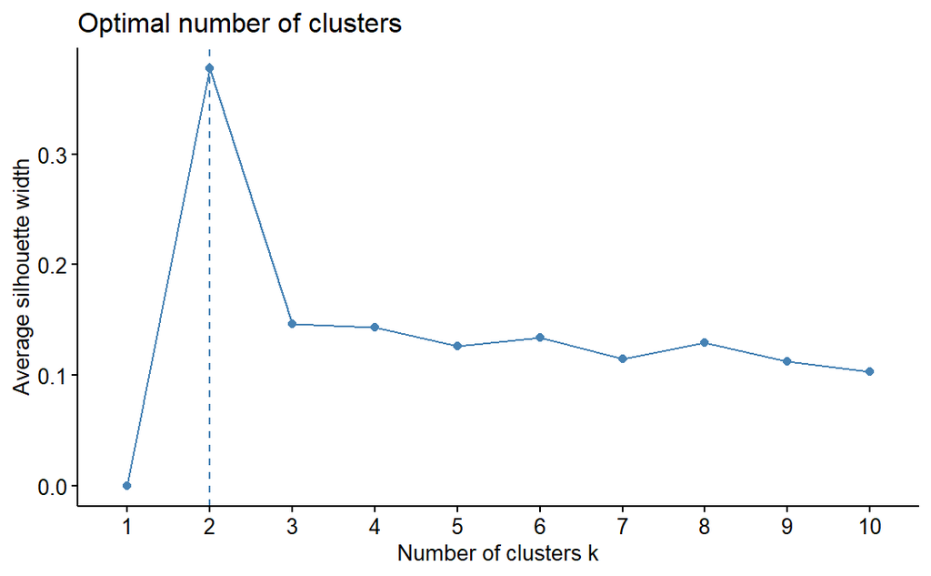

```r
#takes aprox 2 min
fviz_nbclust(scale(X), pam, method = 'silhouette', k.max = 10)
```

[output not shown]

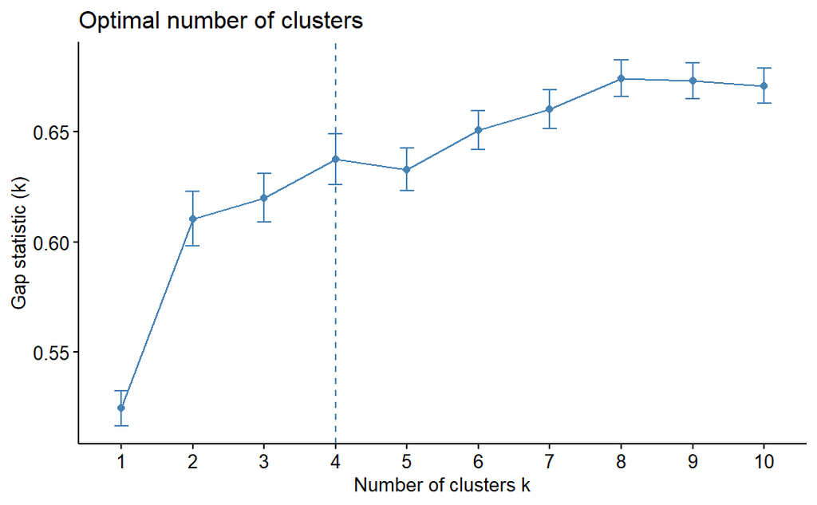

```r
fviz_nbclust(scale(X), pam, method = 'gap_stat', k.max = 10, nboot = 500)
```

We see that with the silhouette method we reach the conclusion that 2 clusters are the best, however with the gap_stat method our conclusion is that 4 clusters are the best. So we are going to make the PAM clustering using 3 clusters

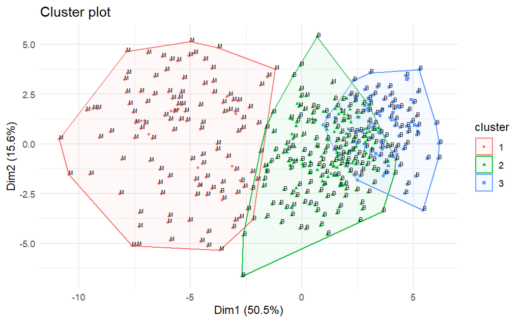

```r
#PAM clustering with 3 clusters
fit.pam <- eclust(scale(X), "pam", stand=TRUE, k=3, graph=F)

fviz_cluster(fit.pam, data = X, geom = c("point"), pointsize=1, ellipse.alpha=0.05)+
  theme_minimal()+geom_text(label=diagnosis,hjust=0, vjust=0,size=2,check_overlap = T)
```

From this plot, we can identify easily 3 different groups. The first cluster contains most of the malignant tumors, the second clusters contains mostly benignant tumors but also some malignant ones, we can interpret from that that those malignant tumors included on cluster 2 are not so advanced. Finally, the third cluster contains the rest of the benignant tumors.

### Optimal number of groups for kernel k means?

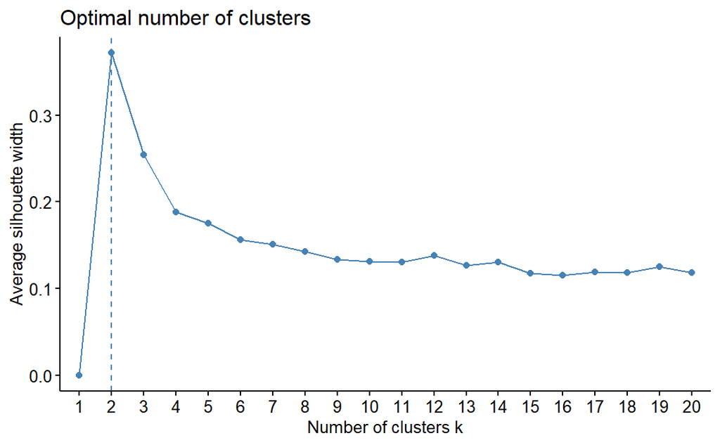

```r
fviz_nbclust(scale(X), kmeans, method = 'silhouette', k.max = 20, nstart = 1000)
```

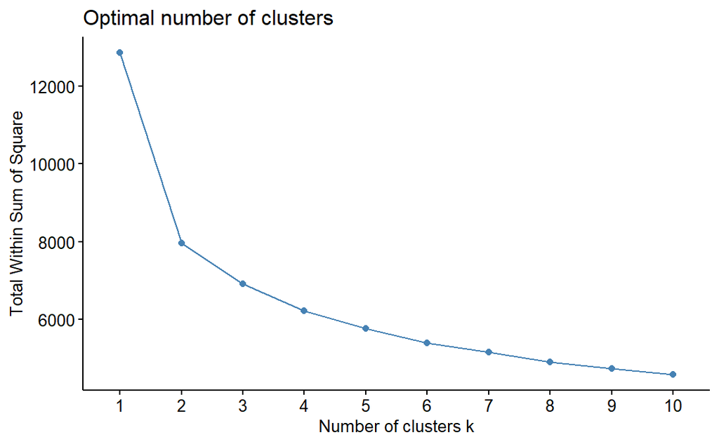

```r
fviz_nbclust(scale(X), kmeans, method = 'wss', k.max = 10, nstart = 1000)
```

We see that the best number of clusters to use in kernel k-means is 2, this is good for us as we want to classify between malignant and benignant, let’s see the plot

### Kernel K-means

```r
library(kernlab)

fit.ker <- kkmeans(scale(as.matrix(X)), centers=2, kernel="rbfdot") # Radial Basis kernel (Gaussian)
```

```
Using automatic sigma estimation (sigest) for RBF or laplace kernel
```

```r
# By default, Gaussian kernel is used
# By default, sigma parameter is estimated

centers(fit.ker)#coordinates of the centroids
```

```
           [,1]       [,2]       [,3]       [,4]       [,5]       [,6]       [,7]       [,8]       [,9]      [,10]
[1,]  0.8465264  0.4283772  0.8772625  0.8505584  0.4744888  0.9226134  1.0257873  1.0204913  0.4780995  0.7907317
[2,] -0.5039522 -0.2550205 -0.5222499 -0.5063525 -0.2824716 -0.5492481 -0.6106694 -0.6075165 -0.2846211 -0.4707366
          [,11]      [,12]      [,13]      [,14]      [,15]       [,16]      [,17]      [,18]      [,19]      [,20]
[1,]  0.8358810  0.8388991  0.7546498  0.7840495  0.7953506  0.04501839  0.5447626  0.8903605  0.4443481  0.9241805
[2,] -0.4976148 -0.4994115 -0.4492564 -0.4667585 -0.4734863 -0.02680025 -0.3243068 -0.5300474 -0.2645283 -0.5501811
          [,21]      [,22]      [,23]      [,24]      [,25]      [,26]      [,27]
[1,]  0.8784358  0.4976360  0.8529568  0.9219581  0.9804795  0.4754617  0.5588710
[2,] -0.5229484 -0.2962515 -0.5077803 -0.5488580 -0.5836968 -0.2830508 -0.3327058
```

```r
size(fit.ker)#Number of obs in each cluster
```

```
[1] 178 299
```

```r
withinss(fit.ker)
```

```
[1] 5320.147 3854.303
```

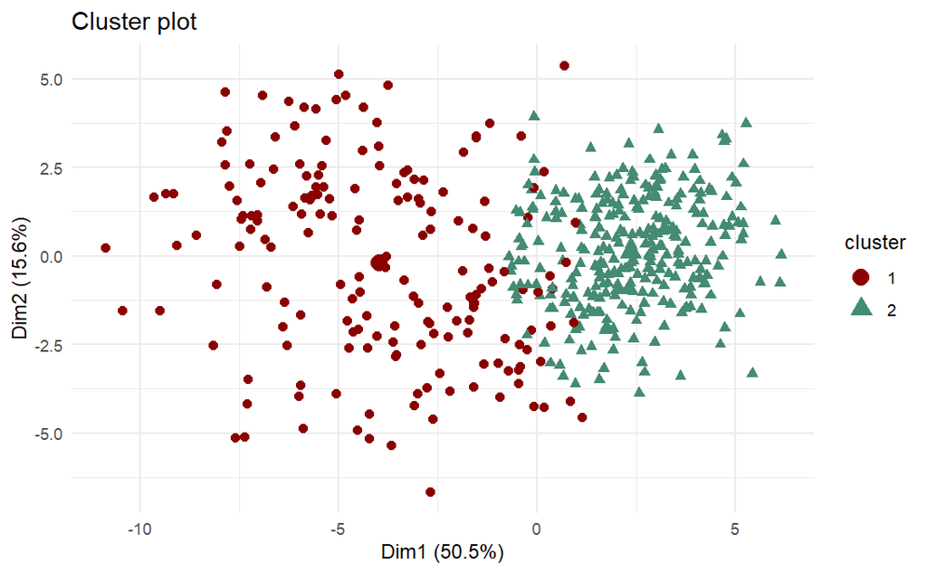

```r
object.ker = list(data =X, cluster = fit.ker@.Data)

fviz_cluster(object.ker, geom = c("point"),pointsize=2, ellipse = F)+ theme_minimal()+scale_color_manual(values = c("darkred", "aquamarine4"))
```

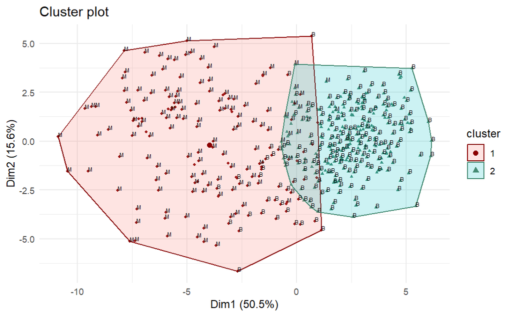

```r
fviz_cluster(object.ker, geom = c("point"), ellipse=
               T,pointsize=1, ellipse.apha = 0.1)+ theme_minimal()+geom_text(label=diagnosis,hjust=0, vjust=0,size=2,check_overlap =  T)+scale_color_manual(values =c("darkred", "aquamarine4"))
```

In this plot we can see perfectly 2 different groups. The first one contains almost all of the patients with malignant tumors and a few of benignant ones, we can interpret from this that the patients with benignant tumors included on cluster 1 are the ones that have to take few more checks in some time for studying the evolution of the tumor.

### Hierarchical clustering

This is a valuable tool for data exploration, visualization, and understanding relationships within a dataset. Its ability to create a hierarchy of clusters without requiring the prior specification of the number of clusters makes it particularly useful in exploratory data analysis and pattern discovery.

Important to decide distance between observations and linkage to join groups

We need to decide first the distance and linkage

```r
d = dist(scale(X), method = "euclidean")
hc <- hclust(d, method = "ward.D2")
```

Visualization

We use k = 2 because we want to classificate the data in benignant and malignant tumors

**Classical dendogram:**

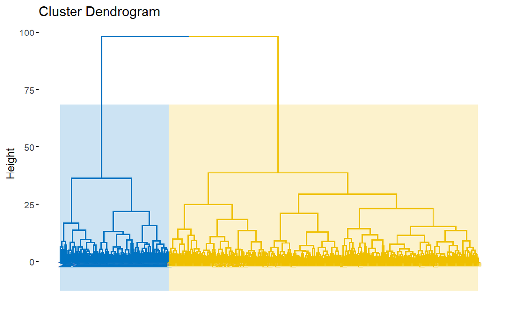

```r
hc$labels <- diagnosis
 #We need to take a sample of the data for making this clusterization
fviz_dend(x = hc,
          k=2,
          palette = "jco",
          rect = TRUE, rect_fill = TRUE, cex=0.5,
          rect_border = "jco")
```

It’s very difficult to analyze that graph as we do not see properly the names of the two hierarchical groups

Let’s use a phylogenic tree instead:

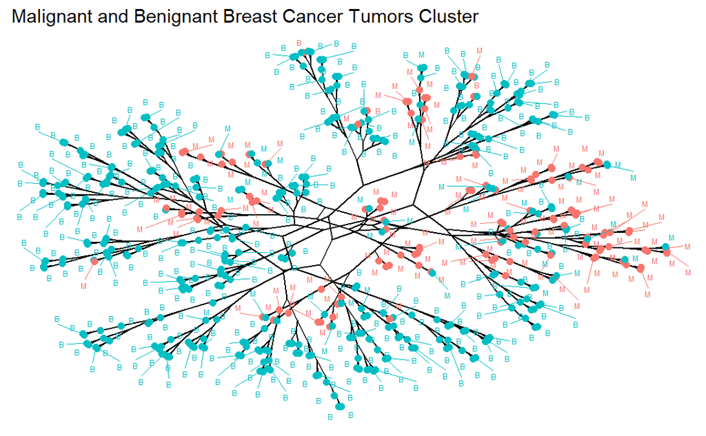

```r
fviz_dend(x = hc,
         k = 2,
          color_labels_by_k = TRUE,
          cex = 0.5,
          type = "phylogenic",
          repel = TRUE)+  labs(title="Malignant and Benignant Breast Cancer Tumors Cluster") + theme(axis.text.x=element_blank(),axis.text.y=element_blank())
```

### EM clustering

Expectation-Maximization clustering is like k-means but computes probabilities of cluster memberships based on probability distributions

Hence, the goal of the EM clustering then is to maximize the overall likelihood of the data, given the (final) clusters

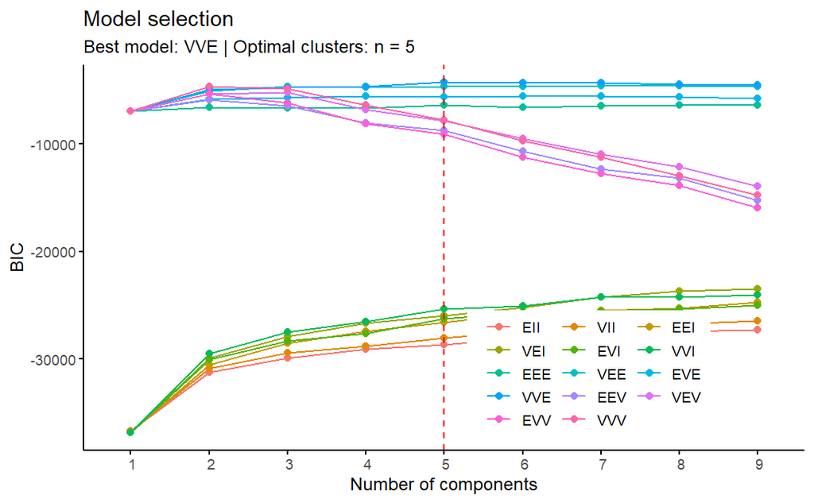

```r
fviz_mclust(object = res.Mclust, what = "BIC", pallete = "jco") +
  scale_x_discrete(limits = c(1:10))
```

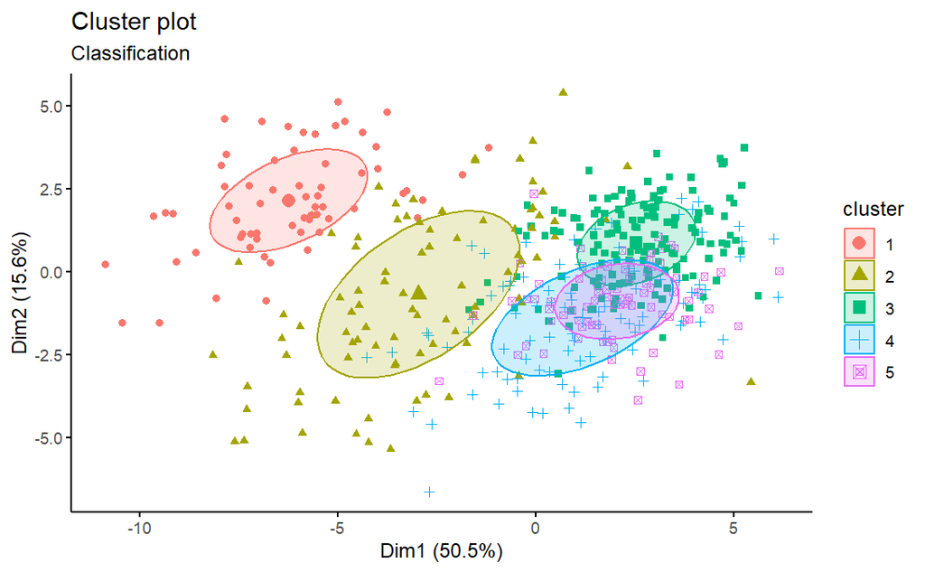

```r
fviz_mclust(object = res.Mclust, what = "classification", geom = "point",
pallete = "jco")
```

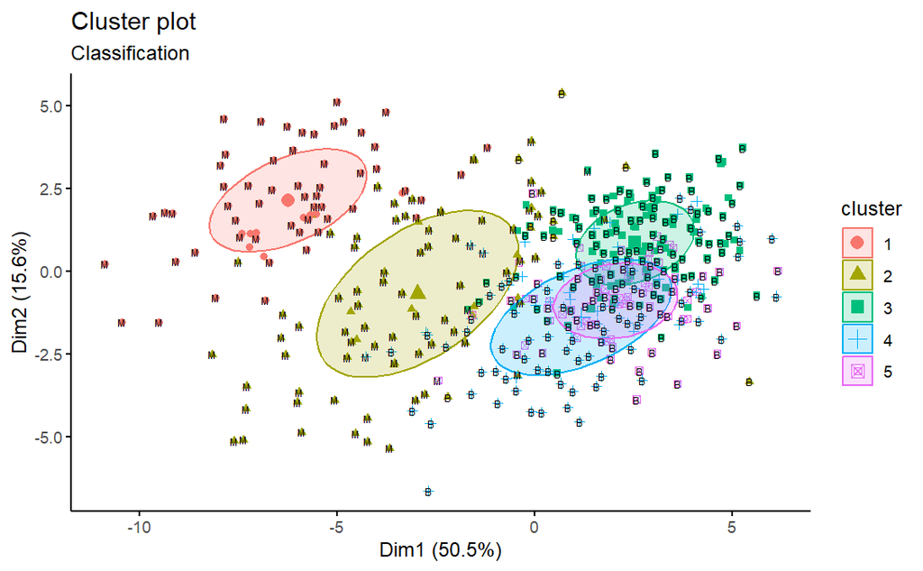

```r
fviz_mclust(object = res.Mclust, what = "classification", geom = "point",
pallete = "jco")+geom_text(label = diagnosis, size = 2, check_overlap = T)
```

Interpretation:

cluster 1: contains all malignant tumors, we can say that this are the most advanced tumors as is the only cluster that does not contain benignant ones

cluster 2: contains mostly malignant tumors and few of benignant ones, this can be interpreted as those benignant tumors may be wrong, for being sure , that patient should get a review again

clusters 3: mostly contains the patients with benignant tumors but also include few malignant ones, as is said previously in the project, this can be because not all the cancer tumors are equally advanced, and, in this case, this factor may contain the patients with less advanced tumors

clusters 4 & 5: contains all benignant tumors

```r
# Computes the adjusted Rand index comparing two classifications.
# The closer to 1 the more agreement
groups.hc = cutree(hc, k = 2)
adjustedRandIndex(res.Mclust$classification, fit.pam$clustering)
```

```
[1] 0.2110113
```

```r
adjustedRandIndex(fit.pam$clustering, t.kmeans$cluster)
```

```
[1] 0.4933837
```

```r
adjustedRandIndex(fit.pam$clustering, groups.hc)
```

```
[1] 0.5009243
```

```r
adjustedRandIndex(t.kmeans$cluster, groups.hc)
```

```
[1] 0.8488448
```

## CONCLUSION

We have done a very interesting study of the patients that have malignant or benignant tumors. The principal goal of this project was if we can classify (or predict) if the patient has a malignant or benignant tumors focus on the characteristics of the breast. We are very happy with the results since not only have we been able to achieve that goal, but we have also realized that these two groups can be subdivided into others dividing the malignant tumors into the ones that are more advanced and the ones that are less. And also the benignant ones in the results with more reliability and others that may be wrong. Breast cancer is a very serious problem that kills thousands of women a year, so we think that these types of studies are very necessary. And we hope they continue to do so